# Alderspensjon

Kapittel 7 i Barr

Published

October 22, 2024

## Introduksjon

- ett av de sentrale budskapene er at avvikene fra først-best økonomi (= markedssvikt) har store konsekvenser for utformingen av effektive pensjonssystemer

## Pensjonenes hovedmål

- konsumglatting
  - individer maksimerer sin nytte over tid, ikke bare på ett tidspunkt
  - pensjoner gjør det mulig å overføre forbruk fra de produktive midtårene til pensjonistårene
  - kan velge sin foretrukne forbrukskurve over livsløpet

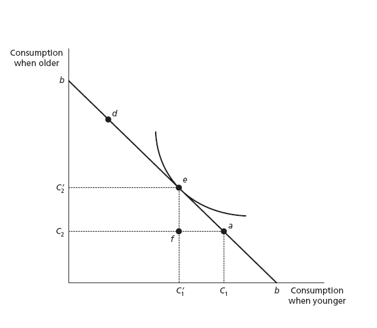

- forsikring
  - i en verden uten sikkerhet, sparer individer i arbeidslivet for å finansiere pensjonen
  - siden ingen vet hvor lenge de vil leve, kan pensjonssparingen risikere å ta slutt før livet gjør det
  - statlig intervensjon er nødvendig
- to grunner gjør statlig inngrep nødvendig:
  - enkle modeller antar ofte en førstbest økonomi og ignorerer markedssvikt
  - offentlig politikk har mål utover forbrukssmoothing og forsikring
    - fattigdomsbekjempelse og omfordeling

### Sekundære mål

- økonomisk vekst
  - dårlig utformede pensjoner kan føre til uheldige arbeidsmarkedsinsentiver
  - gode pensjonssystemer kan støtte arbeids- og kapitalmarkeder samt oppmuntre til sparing

## Effektivitetsargumenter for statlig intervensjon

### Mikroøkonomiske aspekter

## Tilbudssiden: Ufullstendig forsikring

- effektiv konsumglatting krever at enkeltpersoner kjøper det sanfunnsøkonomisk optimale nivået av pensjon
  - ville folk bidratt frivillig til en pensjonsordning?
  - hvorfor gjør staten pensjonsinnbetalingen obligatorisk?
  - hvorfor tilbyr myndighetene pensjoner?

## Ville folk bidratt frivillig til en pensjonsordning?

- i en verden med perfekt informasjon, inkludert sikkerhet om egen forventet levealder, ville konsumglatting skjedd gjennom frivillig sparing
- i praksis vet folk ikke hvor lenge de vil leve, så en blanding av sparing og forsikring er generelt mer effektiv
- en rasjonell, risikoavers person vil derfor frivillig bli med i en pensjonsordning så lenge nettokostnaden ikke overstiger verdien av sikkerheten han dermed oppnår

#### Hvorfor gjør staten pensjonsinnbetalingen obligatorisk?

- argumentet for tvang hviler på de negative eksternalitetene som oppstår hvis en person ikke kjøper pensjonsrettigheter

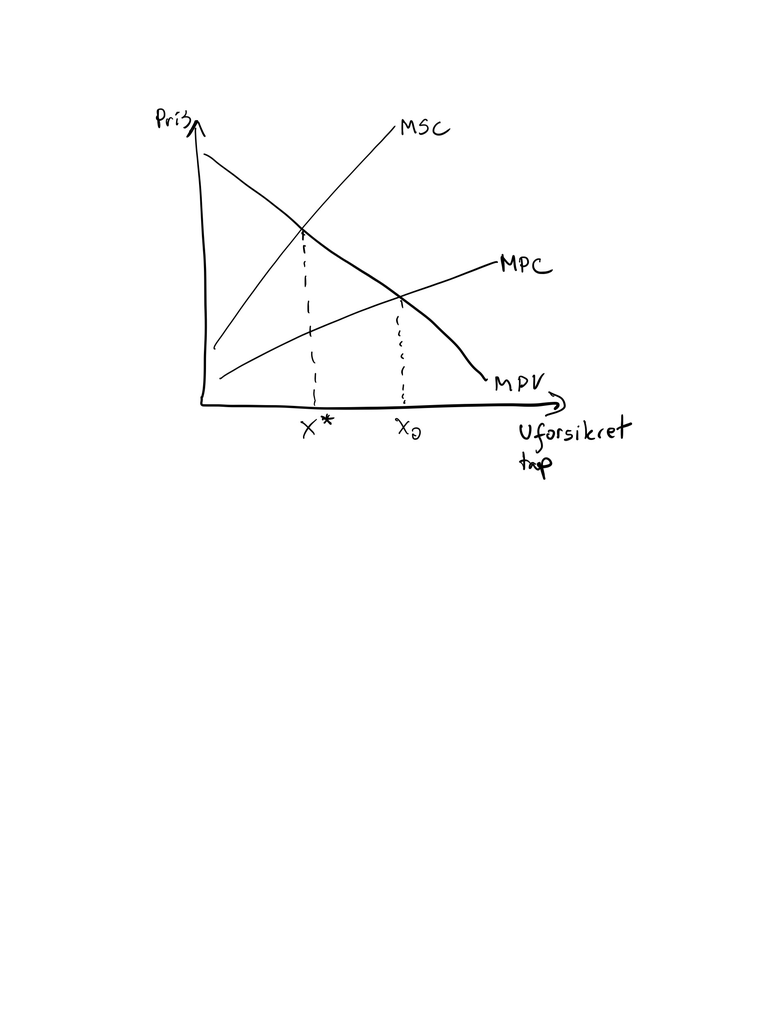

## Hvorfor tilbyr myndighetene pensjoner?

## Tilbudsssiden: pensjonsutbetalinger og inflasjon

- på tilbudssiden oppstår to sett med problemer
  - er markedene for pensjonsutbetalinger effektive?
  - hvordan takler pensjoner inflasjon?
- er forholdene til stede for at det private markedet skal kunne tilby forsikring effektivt?

### Repetisjon: Privat tilbud av forsikring, forutsetninger

$$\pi_i = (1+α) p_iL$$

- de individuelle sannsynlighetene for ulykke/skade ($p_i$) er uavhengig av hverandre (ingen systematisk risiko)
- Må ha usikkerhet, dvs. manglende kunnskap om framtidig utfall $p_i \le 1$
  - om $p_i = 1$, da blir $\pi = (1+α)L > L$
- Risiko, ikke usikkerhet (sannsynlighet må være kjent eller mulig å estimere (forsikringsselskapet må vite gjennomsnittlig $p_i$)
- Ingen asymmetrisk informasjon
  - ingen ugunstig utvalg
  - ingen adferdsrisiko
    - kan påvirke $p_i$ (ex ante -atferdsrisiko)
      - forsikringstakeren kan påvirke sannsynlighet for tap eller størrelse på potensielt tap, gjennom strategisk adferdsendring
      - for eksempel ingen forebygging

## Pensjonsutbetalinger: ville det private markedet kunne tilbudt dem effektivt**

- Sannsynligheten for at pensjonist A lever til en gitt alder er uavhengig av pensjonist B
- risikoen for å leve til en viss alder er mindre enn én
- den gjennomsnittlige risikoen er kjent
  - data om dødelighetsrater er lett tilgjengelige.
- Ved første øyekast er det ingen store problemer med uheldig utvalg og moralsk hasard:
  - folk vet ikke når de skal dø, og selvmord er kostbart for individet og gunstig for forsikringsselskapet
- **utbetalingsmarkedene ser ut til å oppfylle betingelsene for effektiv forsikring**
  - konklusjonen må imidlertid nyanseres
    - et betydelig problem er tendensen til å undervurdere forbedringer i forventet levealder
      - Tidligere døde mange før de nådde pensjonsalderen, og de som levde lenge nok til å motta pensjon, gjorde det i gjennomsnitt bare i en kort periode.
      - med lengre forventet levealder, lever flere til å motta pensjon, og de har flere år med pensjonisttilværelse.
    - dermed utvides «tvilstrakten» om kostnadene ved å tilby en gitt utbetaling
      - reiser spørsmålet om dødelighetsrater bør betraktes som en risiko eller en usikkerhet
      - hvis det underliggende problemet er usikkerhet, vil det sannsynlige resultatet være uforutsette kostnader
    - Norden: kostnadene deles med skattebetalerne
      - staten tilbyr utbetalingene
- **Inflasjon**
  - konsumglatting handler om fremtidig forbruk – den reelle verdien av en persons pensjon
    - kan kun skje uten statlig inngripen dersom det private markedet kan tilby forsikring mot uventet inflasjon
      - er ikke mulig av to grunner:
        - sannsynlighetsfordelingen for ulike fremtidige inflasjonsnivåer er ukjent
        - inflasjon er et felles sjokk
          - sannsynligheten for at pensjonist A opplever en gitt inflasjonsrate er ikke uavhengig av pensjonist B – inflasjonsraten for en pensjonist vil (i stor grad) være den samme for alle.

## Etterspørselssiden: Informasjons- og atferdsproblemer

- spørsmålet på etterspørselssiden er om folk er i stand til å ta gode valg om pensjonen sin **hvis pensjonen var tilbudt på private markeder**
- i teorien om sparing i en først-best økonomi:
  - individet står overfor et komplett utvalg av markedsalternativer til konkurransedyktige priser
  - gjør valg om sparing, porteføljevalg, fondsforvalter og utbetalinger som maksimerer deres livsløpsnytte
  - gitt opprinnelig omfordeling, maksimerer forbrukervalget nytten
  - denne enkle konklusjonen baserer seg på mange antakelser

### Informasjonsproblemer

- optimale pensjonsvalg krever at folk forstår usikkerhetene de står overfor og alternativene markedene tilbyr
- på grunn av manglende framsyn, kunnskap, vilje eller evne vil mange **utsette pensjonssparingen så lenge at den blir for kostbar eller for liten**.
  - enkeltpersoner er ofte dårlig informert på flere måter
    - en dårlig forståelse av risikoene de står overfor, for eksempel når det gjelder fremtidige fordeler fra ulike typer pensjoner
    - mange mennesker er ikke kjent med forskjellen mellom ytelsesbaserte ordninger og innskuddsbaserte ordninger
    - mange har dårlig forståelse for sannsynligheter
    - mange individer forstår ikke grunnleggende begreper innen finans
- problemet har også fordelingsmessige implikasjoner, siden informasjonsfattigdom og økonomisk fattigdom er nært knyttet sammen

### Atferdsproblemer

- **begrenset viljestyrke** (“vil ikke”)
  - individer vet hva som er den riktige pensjonsstrategien, men klarer ikke å gjennomføre den
  - selv om mange vet at de bør spare mer, gjør de det ofte ikke
    - nyere eksperimentelle data: folk har en høyere diskonteringsrate på kort sikt (det vil si en tendens til øyeblikkelig tilfredsstillelse) og en lavere på mellomlang sikt
      - problemet er at når fremtiden ankommer, blir den til nåtiden
        - dermed fortsetter kortsiktig tilfredsstillelse, noe som fører til inkonsistente tidsvalg:
          - korttidstilfredsstillelse:
            - noen arbeidstakere tar kanskje ikke tid til å velge godt
            - de kan bli påvirket av nåværende insentiver
              - gaver
              - mange går av med pensjon så snart de har lov til det selv om det etterlater dem i fattigdom
          - prokrastinering (utsettelse):
            - folk er enige om at de bør spare mer til pensjon, men utsetter sparingen; sparer ikke; eller sparer ikke nok
          - inertia (inaktivitet)
            - med rasjonelt valg burde det ikke spille noen rolle om noen automatisk blir meldt inn i en spareplan eller må ta eksplisitt handling for å bli med
              - i praksis fører automatisk innmelding til mye høyere deltakelse
- **begrenset rasjonalitet** (“kan ikke”)
  - de fleste pensjonsprofukter er for komplekse til at en person kan ta gode beslutninger, selv når de får den nødvendige informasjonen
    - problemer er mer sannsynlige
      - når tidshorisonten er lang
      - involverer komplekse sannsynligheter
      - detaljene er iboende komplekse
  - fører til dårlige pensjonsvalg på flere måter:
    - **Framing:** folk gjør forskjellige valg avhengig av hvor mange alternativer de står overfor, rekkefølgen de presenteres i, og om presentasjonen er i en tabell eller et diagram
    - **Kjennskap:** En vanlig feil er at en arbeidstaker investerer tungt i aksjene til sin arbeidsgiver. Hvis selskapet går konkurs, mister arbeidstakeren både lønnsinntekt og mye av pensjonsoppsparingen. Slik atferd viser manglende forståelse for fordelene ved å diversifisere risiko.
    - **Overdreven trading:** Mange handler for mye på aksjemarkedet, noe som medfører handelskostnader. Noen prøver å «time» markedet, ofte med negative resultater.
    - **Inaktivitet:** Når de står overfor kompleksitet, gjør noen ingenting, som en kanin fanget i frontlyktene på en bil.
- Disse begrunnelsene taler i større og mindre grad for at deler av standardsikringen i det samlede pensjonssystemet bør ivaretas ved en obligatorisk, inntektsbasert pensjon for alle yrkesaktive
- argumentene for obligatorisk standardsikring taler imidlertid ikke for at hele standardsikringen trenges å organiseres slik
- en allmenn, obligatorisk pensjonsordning kan være offentlig, men den trenger ikke å være det
  - kan også organiseres som **obligatoriske krav** om tjenestepensjon for alle yrkesaktive, eller som **krav om individuell pensjonsforsikring**

## Rettfedighetsargumenter for offentlige inngrep

### Offentlig versus privat pensjonsordning

- ligner på diskusjonen om rettferdighet i forelesningen om trygd
- horisontal rettferdighet handler om **mål som garanterte minimumsstandarder og like muligheter og lik tilgang**
  - disse mål kan oppnås uten offentlige inngrep hvis individer har perfekt informasjon, en argumentasjon som gir liten støtte til offentlig pensjonsordning
  - hvis individer ikke har perfekt informasjon, ville de generelt kunne kjøpe den
- I beste fall finnes det en sak for regulering av minimumsstandarder
- det faktum at individer ikke har lik makt gir ytterligere støtte til minimumsstandarder, men igjen er det ingen sterk argumentasjon for offentlig pensjonsordning
- offentlig pensjonsordning kun for å fremme omfordeling er rettferdiggjort bare av en forbrukseksternalitet, der de rike gir pensjoner til de fattige som et formyndergode
- når det er mest **effektivt** at det offentlige tilbyr pensjonsording, er det ikke upassende å finansiere den gjennom omfordeling
- medlemskapet er også obligatorisk
  - ved å innføre en felles løsning, unngår man de verste problemene med ugunstig utvalg
- Disse effektivitetsargumentene for tvang og offentlig pensjonsordning, samlet sett, antyder at bruk av offentlig organiserte pensjoner til omfordelingsformål ikke nødvendigvis forårsaker betydelige effektivitetskostnader

### De omfordelende effektene av pensjoner

- intergenerasjonell omfordeling
  - Et PAYG-system (Pay-As-You-Go) gjør det mulig for en hel generasjon å motta mer enn summen av sine tidligere bidrag
  - i et fullt finansiert ytelsesbasert system, forutsatt ingen inflasjon, er fordelene til enhver generasjon begrenset til dens tidligere bidrag, og omfordeling fra unge til gamle er utelukket
  - effekten av uventet inflasjon kan føre til utilsiktet omfordeling fra gamle til unge, og omvendt ved uventet prisdeflasjon
- omfordeling fra rik til fattig
  - I mange ordninger er det en formelbasert omfordeling, der individ B med halvparten av inntekten til individ A betaler halvparten av bidraget, men mottar en pensjon som er mer enn halvparten av A sin
- Andre faktorer virker i motsatt retning:
  - folk med høyere inntekt har en lengre forventet levealder
  - får derfor pensjon i lengre tid
  - også en tendens til å være lengre i utdanning, og begynner dermed å betale bidrag senere

## Pensjonssystemet i Norge

- dagens norske alderspensjonssystem bygger på et pay-as-you-go-system (PAYG)
  - dagens skatter finansierer dagens pensjonsutbetalinger
  - prinsippet kan føres tilbake til teorien om en overlappende generasjonsmodell (Samuelson, 1958)
  - man går over livsløpet gjennom ulike faser, hvor man er produktiv i arbeidsfør alder og ikke arbeider i siste del av livet
    - man ønsker å konsumere relativt jevnt over hele livsløpet, også som pensjonist
  - teorien viser at det bør inngås en samfunnskontrakt mellom de som er i arbeid og de som er pensjonister ved at det overføres penger fra de sysselsatte til pensjonistene
    - de som erpensjonister i dag, har stått ovenfor den samme kontrakten da de var i arbeid og finansierte pensjonene til de som var pensjonister da
    - de som er i arbeid vil stå overfor den samme samfunnskontrakten når de i fremtiden blir pensjonister.

## Mål og prinsipper for det norske pensjonssystemet

- Hovedmålet er økonomisk og sosial trygghet for alle pensjonister
- Pensjonssystemet skal sikre både grunnsikring (minstepensjon) og standardsikring (pensjon basert på inntekt)
- Pensjonen fungerer som en forsikring mot usikkerhet knyttet til levealder, helse og økonomiske forhold
- Sosial omfordeling er sentralt for å redusere økonomiske forskjeller blant pensjonistene

# Pensjonsforliket 2024

## Behov for pensjonsreformer

- leveealderen i Europa har økt betydelig samtidig som fødselstallene er stabilt lave
  - befolkningen eldes
  - flere pensjonister å forsørge for hver yrkesaktiv
  - denne demografiske utviklingen har vært synlig lenge, og ligger ikke an til å bli reversert
  - utgiftene til pensjon øker
    - pensjonssystemets bærekraft må sees i sammenheng med bærekraften i offentlige finanser
    - mindre offentlige midler igjen til andre formål?
    - skattene må økes betraktelig?
    - senke pensjonene?
      - skaper mer fattigdom og dårligere levekår blant pensjonister
        - politisk upopulært
- dette dilemmaet berører også beslutningstakere i Norge
  - selv om aldringen av den norske befolkningen går saktere enn i mange andre land
  - Norge har en svært solid offentlig økonomi
- siden 1990-tallet har en rekke europeiske land gjennomført omfattende pensjonsreformer
  - tre hovedstrategier (Hinrichs 2021):
    - å senke nivået på pensjonene
      - øker ikke ytelsene i takt med pris- og/eller lønnsnivå i samfunnet
      - reduserer hvor stor andel av tidligere lønn som legges til grunn for pensjonen
      - knytter nivået på den årlige ytelsen til endringer i forventet levealder
    - **å oppmuntre flere til å jobbe lenger**
      - den enkeltes forventede periode som pensjonist øker mindre enn den forventede levealderen
        - nedskalerer eller avvikler tidligpensjonsordninger
        - øke pensjonsalderen
        - betaler høyere årlige pensjoner til arbeidstakere som står lenge i jobb
    - å styrke ikke-statlige elementer i pensjonssystemet
      - oppmuntrer til privat sparing eller sparing i arbeidsforhold (tjenestepensjoner)
      - vil typisk ha form av skattefordeler

## Hovedtrekk i det siste pensjonsforliket

- Pensjonsalderen skal økes med rundt 1,5 måned for hvert år, og med ett år for hvert tiår. Det vil si at 1974-årgangen må jobbe ett år lenger enn 1964-årgangen, 1984- årgangen må jobbe 2 år lenger og 1994 årgangen 3 år lenger.
- De som slutter tidlig, vil kompenseres med et slitertillegg på inntil 0,25 G årlig. I dag tilsvarer det i underkant av 30.000 kroner. Vilkår og regler for denne ordningen skal utarbeides i samarbeid med partene i arbeidslivet.
- De som er uføre, inkludert noen tidligere uføre som allerede er alderspensjonister, får en bedre alderspensjon gjennom et skjermingstillegg.
- For statsansatte heves den alminnelige aldersgrensen fra 70 til 72 år, tilsvarende gjeldende bestemmelse i arbeidsmiljøloven.
- Minstesatsene skal reguleres i takt med lønnsveksten, og alle alderspensjoner under utbetaling skal fortsatt reguleres med gjennomsnittet av lønns- og prisveksten. Dermed vil ytelsene opprettholde verdien sin i tråd med det generelle lønnsnivået i samfunnet.

# Økonomisk bærekraft

- Økonomisk bærekraft er en hovedprioritet for pensjonssystemet
- Økonomisk bærekraft gir trygghet for fremtidens pensjoner
- Press på pensjonssystemet kommer fra lengre levealder og svakere vekst i yrkesaktiv befolkning
- Stabilisering av utgiftene er en forutsetning for et bærekraftig system.
- Levealdersjusteringen er en sentral mekanisme for å dempe presset på pensjonsutgiftene.
- Økt yrkesdeltakelse kan bidra til bedre finansieringsgrunnlag gjennom økte skatteinntekter.

## Demografi og økonomiske utfordringer

- Økning i forventet levealder gjør levealdersjustering nødvendig for å opprettholde bærekraften
- Reduksjon i antall personer i yrkesaktiv alder skaper utfordringer for finansieringen av pensjonene

## Endringer i befolkningssammensetning fører til økt forsørgelsesbyrde

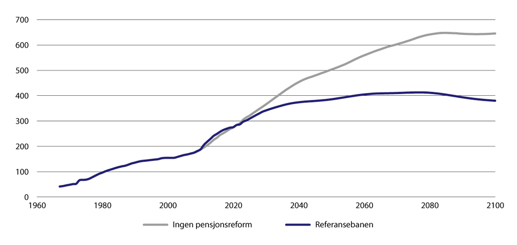

Utgifter til alderspensjon fra folketrygden. Mrd. 2023-kroner (lønnsdeflatert). Framskrevet etter 2022 Kilde: Statistisk sentralbyrå

## Flere eldre vil legge press på offentlige finanser

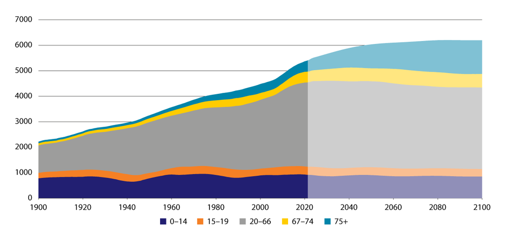

Befolkning fordelt på aldersgrupper 1900 til 2100 i 1000 personer. Registrert og middelalternativet i befolkningsframskrivingene fra 2022 (BF2022). Kilde: Statistisk sentralbyrå

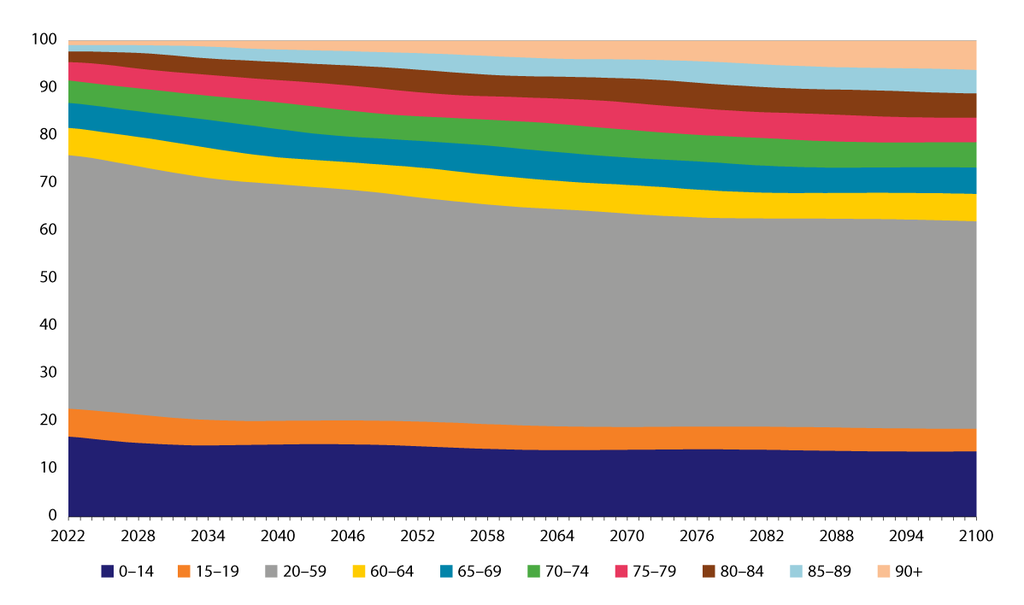

Prosentandel av befolkningen etter aldersgrupper, framskrevne tall middelalternativet i befolkningsframskrivingene fra 2022. Kilde: Statistisk sentralbyrå

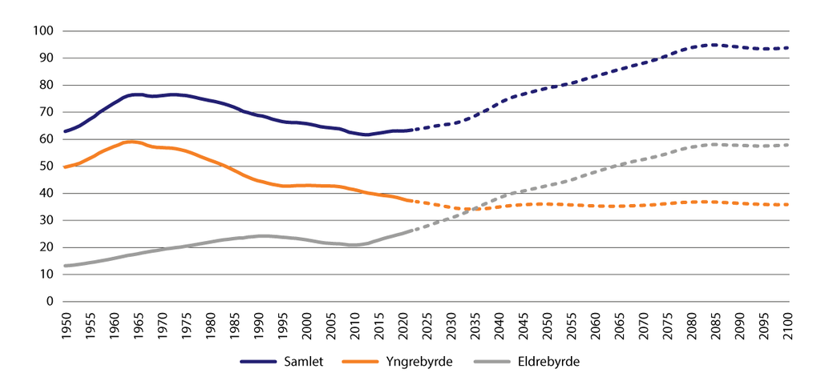

Utviklingen i samlet forsørgelsesbyrde 1950–2100. Prosent. Historiske tall 1950–2022. Framskriving 2023–2100 fra middelalternativet i befolkningsframskrivingen 2022.Kilde: Statistisk sentralbyrå.

## Å oppmuntre flere til å jobbe lenger: insentiver til arbeid og utviklingen i yrkesaktiviteten etter pensjonsreformen

- styrket insentivene til å forbli lengre i arbeidslivet
- Pensjonsopptjening er nå tettere knyttet til arbeidsinntekten hvert år
- Fleksibelt uttak av pensjon gir insentiv til å utsette pensjonsuttaket for å få høyere utbetalinger
- Eldre arbeidstakere har hatt økt yrkesdeltakelse siden forrige reformen i 2011
- Tre viktige elementer påvirker arbeidsinsentiver:
  1. Alleårsopptjening
  2. Fleksibelt uttak av pensjon
  3. Levealdersjustering

## Økonomiske insentiver i folketrygdens alderspensjon

- før reformen i 2011
  - før reformen ga arbeid opptjening til alderspensjon til 70 år
  - opptjening utover 40 år ga normalt ikke økt pensjon
  - arbeidsinntekt ble avkortet mot pensjonen ved tidlig uttak
- etter reformen i 2011:
  - Alleårsopptjening: **opptjening gjennom hele yrkeslivet** (fra 13 til 75 år)
  - Private sektor: AFP ble omgjort til livsvarig tillegg.
  - Offentlig sektor: Vurdering av insentiver for ansatte født før 1963
    - Reformen styrket insentivene til å jobbe lengre
    - Tett sammenheng mellom arbeidsinntekt og pensjonsopptjening
    - Nøytrale uttaksregler stimulerer til senere pensjonering for høyere utbetalinger

## Utvikling i yrkesaktivitet og avgangsalder etter 2011

- Økt yrkesdeltakelse blant eldre etter reformen
- flere velger å stå lengre i arbeid for å kompensere for levealdersjustering

## Avgangsalderen har økt, men flere må jobbe lengre for å sikre pensjonsnivået

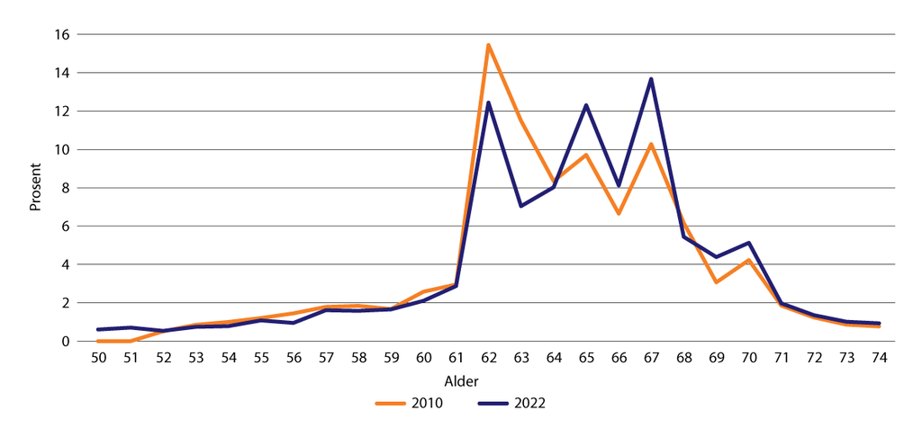

Avgang fra arbeidslivet i 2010 og 2022 etter avgangsalder. Andel i prosent. Kilde: Arbeids- og velferdsdirektoratet.

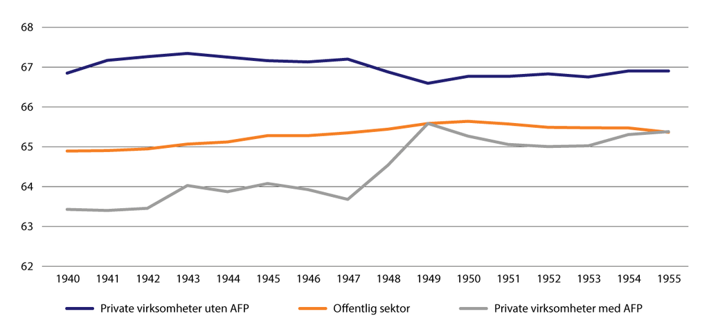

Median avgangsalder blant arbeidsføre etter sektor og fødselsår. Kilde: Arbeids- og velferdsdirektoratet.

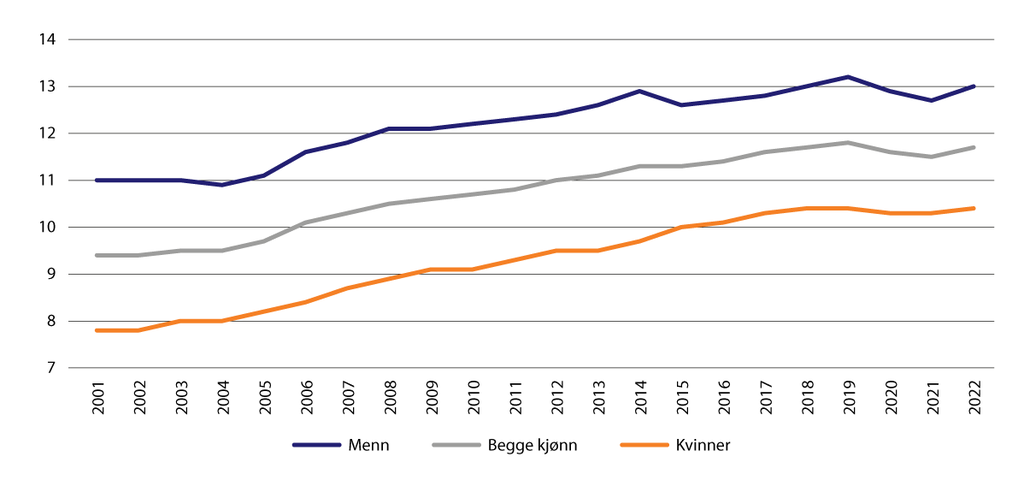

Forventet yrkesaktivitet etter fylte 50 år. Årsverk. Kilde: Arbeids- og velferdsdirektoratet.

### Betydningen av god informasjon

- God informasjon om pensjonsvalg er avgjørende for informerte beslutninger
- Pensjonsportaler gir bedre oversikt over opptjening og mulige pensjonsvalg
- Prognoser viser konsekvensene av ulike pensjonsuttak

### Andre faktorer som påvirker pensjoneringsbeslutningen

- Faktorer som påvirker når folk velger å pensjonere seg:
  - Trivsel på jobben
  - Helsetilstand
  - Familieforhold og ektefelles pensjonering
  - Arbeidsmarkedssituasjonen for eldre arbeidstakere

## Levealdersjustering og fleksibel pensjon

- henger tett sammen, og oppmuntrer folk til å jobbe lenger for å kompensere for reduserte ytelser
- **Levealdersjustering**: Pensjonen reduseres når levealderen øker, for å opprettholde systemets bærekraft
  - utbetalingene justeres basert på forventet levealder i befolkningen
  - yngre årskull må jobbe lenger for å få samme årlige pensjon som eldre årskull
  - Økt levealder betyr at oppsparte midler fordeles over flere år, som reduserer årlig pensjonsutbetaling hvis man går av med pensjon tidlig
  - sikrer økonomisk bærekraft i pensjonssystemet på lang sikt
- **Fleksibelt uttak**: Gir mulighet til å ta ut pensjon mellom 62 og 75 år.
  - Mulighet for å kombinere arbeid med delvis eller hel pensjon uten avkorting
  - Pensjon kan tas ut helt eller delvis fra fylte 62 år.
  - Utsatt uttak gir høyere årlig pensjon, mens tidlig uttak gir lavere pensjon.
  - Nøytrale uttaksregler: Total pensjonsutbetaling over tid skal være den samme uansett uttakstidspunkt, avhengig av levealder
  - Fleksibiliteten bidrar til individuell frihet til å velge pensjoneringsalder

## Pensjonsreformen i 2011 har gjort at flere står i jobb lengre

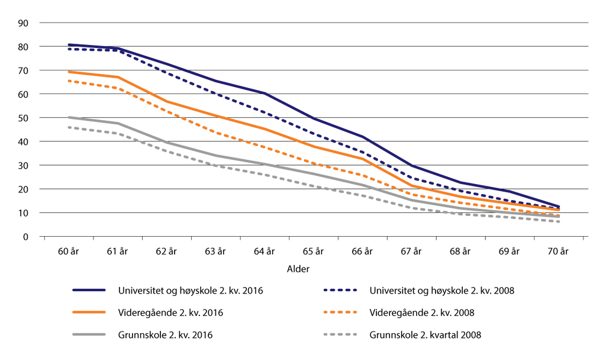

Lønnstakerprosent etter alder og utdanningsnivå for bosatte 60–70 år. Prosent av befolkningen i samme alder 2. kvartal 2008 og 2. kvartal 2016. Kilde: Nordby og Nesheim (2017).

## Sosiale og økonomiske utfordringer

- Levealdersjusteringen kan skape utfordringer for grupper som ikke kan jobbe lengre grunnet helseproblemer.
- Regjeringen vurderer tiltak for såkalte “slitere” som ikke kan utsette pensjonering og derfor ikke kan kompensere for levealdersjusteringen.
- Slitergrupper er et viktig tema for å sikre pensjonssystemets legitimitet.
- Siden folketrygden utbetaler livsvarige pensjoner, er like regler til fordel for de som lever lenge. Selv om ulike grupper har ulik forventet levealder, er regjeringen enig med utvalget i at reglene for levealdersjustering bør være like for alle i et gitt årskull.

## Levealder og yrke - menn

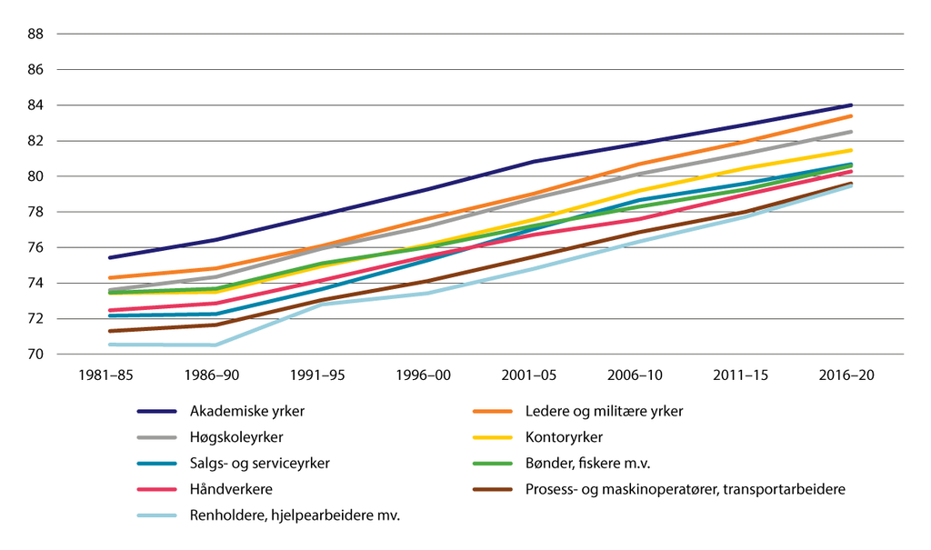

Forventet levealder ved fødselen i ni yrkesfelt for menn. År. Femårsperioder 1981–2020. Kilde: Texmon (2022).

## Levealder og yrke - kvinner

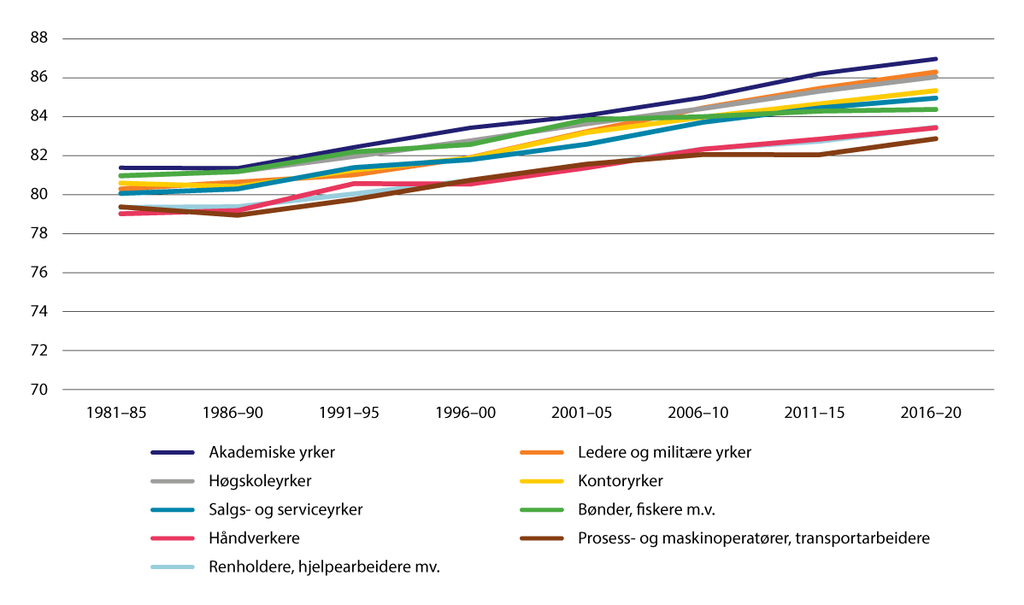

Forventet levealder ved fødselen i ni yrkesfelt for kvinner År. Femårsperioder 1981–2020. Kilde: Texmon (2022).

### Mer detaljert om aldersgrensene

- Aldersgrensene i pensjonssystemet er sentrale for å balansere pensjonsytelser med bærekraften til systemet.
- Pensjonssystemet har tre viktige aldersgrenser:
  1. Laveste alder for tidlig uttak (62 år)
     - Tidlig pensjon gir lavere årlige utbetalinger fordi ytelsene fordeles over flere år
  2. Normert pensjoneringsalder (67 år)
     - alderen hvor de fleste har full pensjonsopptjening.
     - De som tar ut pensjon ved 67 år har rett til minstenivåer og vil ikke bli avkortet på grunn av arbeid ved siden av
  3. Øvre grense for opptjening og uttak (75 år)
  - Det er mulig å utsette uttaket av pensjon til etter 67 år, med økt årlig pensjon som resultat.
  - Utsatt pensjon gir økt pensjonsopptjening, som belønner personer som velger å fortsette å jobbe lenger

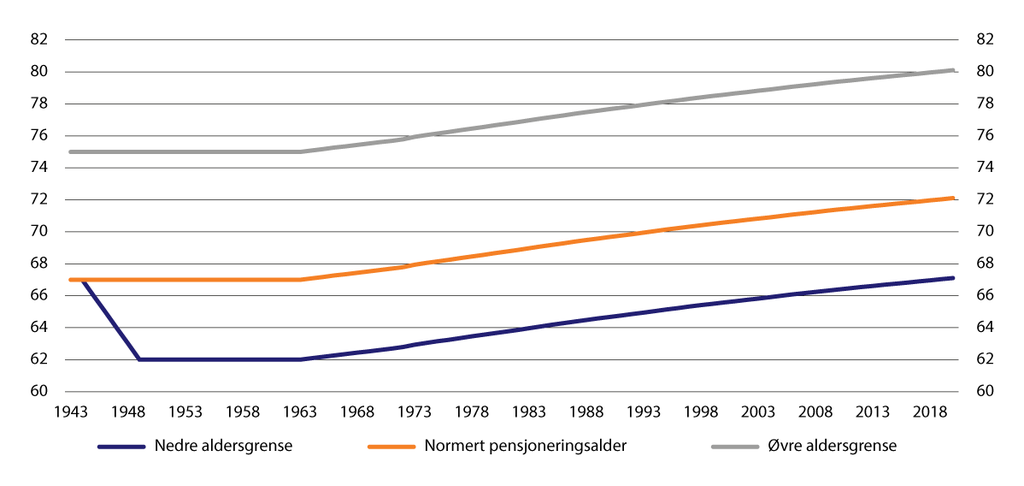

Aldersgrensene i pensjonssystemet for årskullene 1943–2020. Framskrevet fra 1964-årskullet. Alder. Kilde: Arbeids- og velferdsdirektoratet og Statistisk sentralbyrå

### Økende aldersgrenser i tråd med levealder

- Aldersgrensene i pensjonssystemet skal justeres i takt med økt levealder for å opprettholde økonomisk bærekraft
- Justeringen sikrer at pensjonssystemet fortsatt kan gi tilstrekkelige ytelser uten å øke kostnadene dramatisk
- Personer født etter 1964 vil ha høyere pensjonsaldersgrenser for å kompensere for lengre levetid

### Konsekvenser av økte aldersgrenser

- Økte aldersgrenser oppmuntrer folk til å stå lenger i arbeid og oppnå høyere pensjon.
- Justeringen gir mer rettferdige pensjonsytelser ved å tilpasse utbetalingene til forventet levealder.
- For personer med helseutfordringer eller i tungt fysisk arbeid vurderes spesialordninger for tidligere pensjonering.